# Homework 1

Francesca Sallicati

11 maggio 2018

The network chosen for this assignment consist in a human brain functional interactions network. Nodes are regions covering the whole human brain while edges are weighted by the Jaccard index between patterns of activation across experiments.

Analyze the network by answer the following questions:

### 1. What is the number of nodes and links?

```r
data <- readMat("Coactivation_matrix.mat")
matrix <- as.matrix(data$Coactivation.matrix)
g <- graph.adjacency(matrix, mode="undirected", weighted=TRUE)
```

After having created the graph of the network from the available matlab Coactivaction Matrix, by using the functions vcount() and ecount() we can learn that the networks is made by 638 nodes and 18625 edges.

```r
vcount(g)
```

```
## [1] 638
```

```r
ecount(g)
```

```
## [1] 18625
```

### 2. What is the average degree in the network? And the standard deviation of the degree?

```r
mean(degree(g))
```

```
## [1] 58.38558
```

```r
sd(degree(g))
```

```
## [1] 33.74145
```

### 3. Plot the degree distribution in linear-linear scale and in log-log-scale. What is the degree of the most connected node?

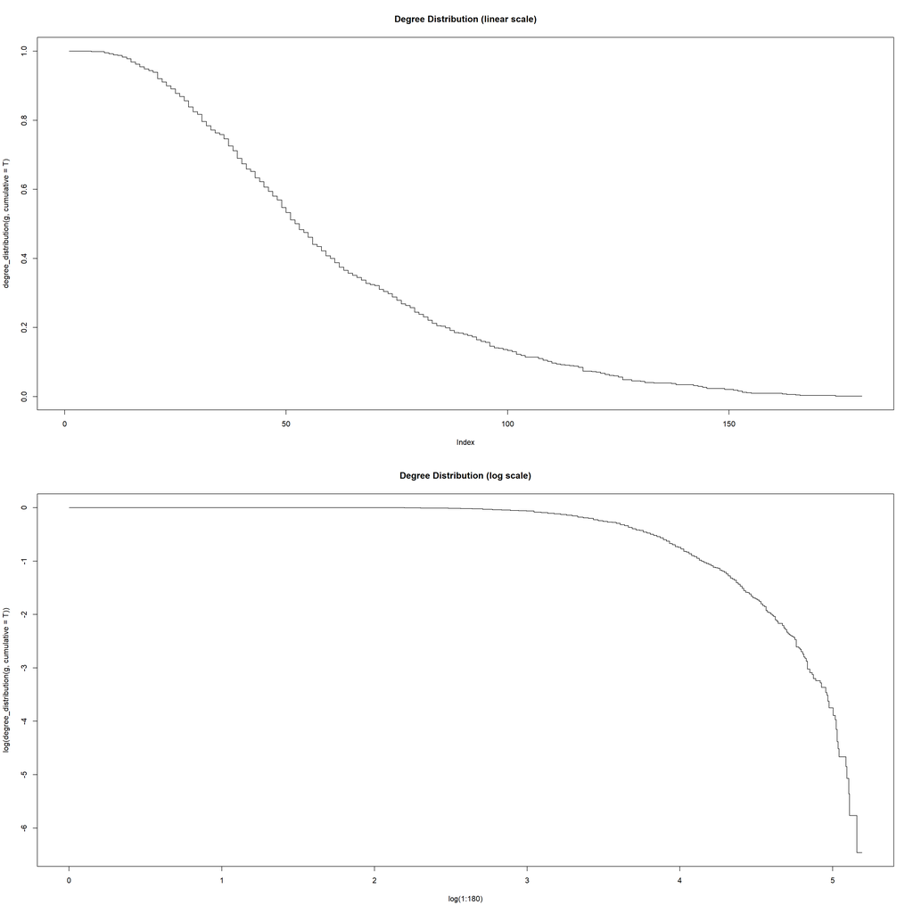

```r
par(mfrow=c(2,1))
plot(degree_distribution(g, cumulative=T),type="s", main="Degree Distribution (linear scale)")
plot(log(1:180),log(degree_distribution(g, cumulative=T)), type="s", main="Degree Distribution (log scale)")
```

```r
which.max(degree(g))
```

```
## [1] 331
```

```r
max(degree(g))
```

```
## [1] 179
```

The highest degree in the network is 179 belonging to node 331.

### 4. What is the clustering coefficient (transitivity) in the network?

```r
transitivity(g)
```

```
## [1] 0.4100847
```

### 5. What is the assortativity (degree) in the network?

```r
assortativity_degree(g)
```

```
## [1] 0.3761221
```

The Pearson coefficient gives a positive value, meaning that the correlation between nodes is positive; thus nodes of similar degree tends to be connected to each other.

### 6. Using the Louvain method, does the network have a community structure? If so, what is its modularity?

```r
commUW<- cluster_louvain(g,weights=NULL)
comm<- cluster_louvain(g,weights=E(g)$value)
sizes(comm)
```

```
## Community sizes
##   1   2   3   4   5
## 116 113 219 112  78
```

```r
modularity(comm,weights=E(g)$value)
```

```
## [1] 0.4674459
```

The cluster louvain algorithm found 5 communities and the resulting modularity is equal to 0.467.

### 7. Test that the clustering coefficient in the network cannot be statistically explained by a configuration model in which the nodes have the same degree as the original.

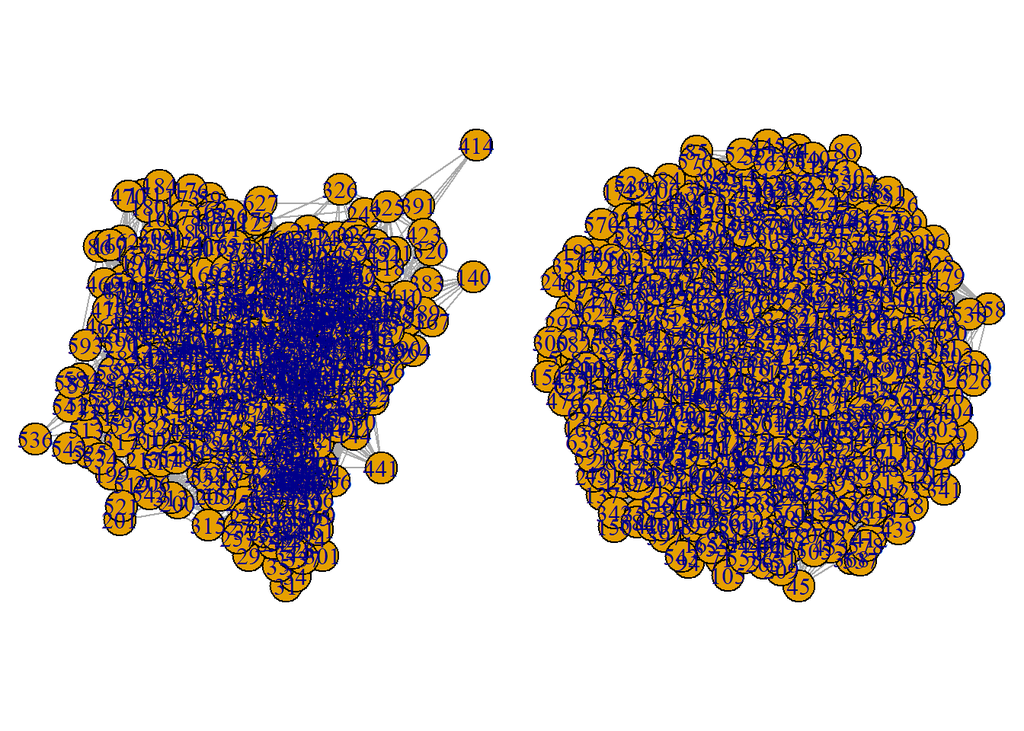

```r
par(mfrow=c(1,2),mar=c(0, 0, 0, 0))
model1 <- erdos.renyi.game(vcount(g),p.or.m=ecount(g),type="gnm")
plot(g);plot(model1)
```

From the graphical comparison we can learn a wide difference between the real network and the Erdos Reny implemented with the number of nodes and edges of the original.

```r
c(mean(degree(g)),mean(degree(model1)))
```

```
## [1] 58.38558 58.38558
```

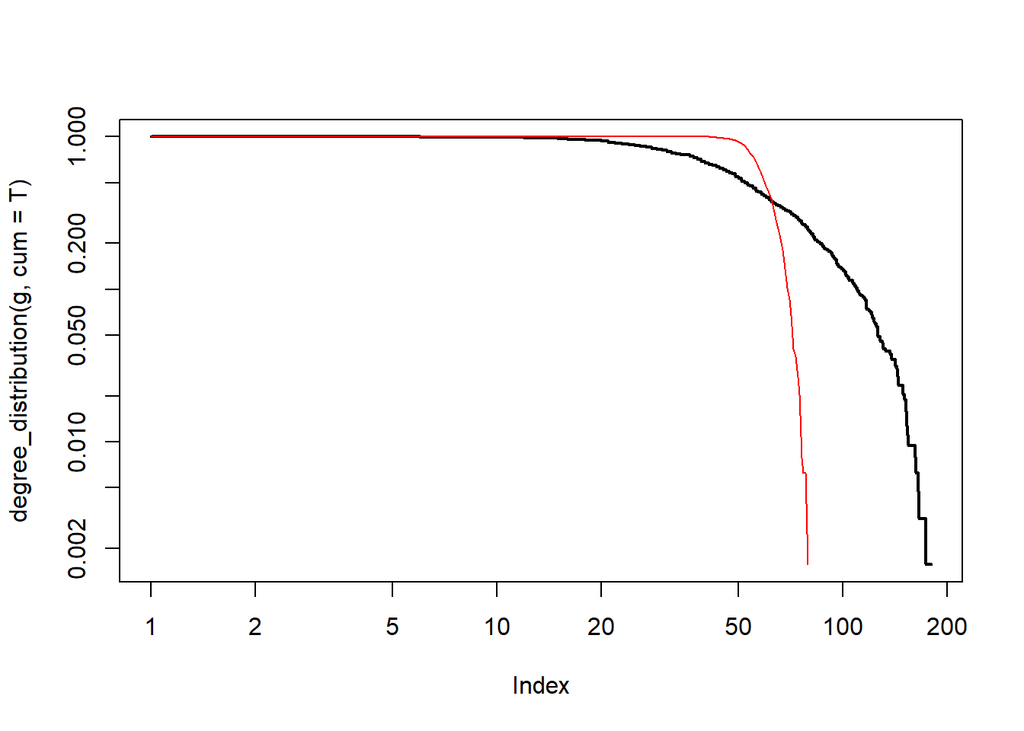

```r
plot(degree_distribution(g,cum=T),type="s",log="xy", lwd=2)
lines(degree_distribution(model1,cum=T),col="red")
```

As one would expect the average degrees of the two networks are the same, however the degree distribution are different, with the a more rapid decrease in the artificial one.

```r
c(diameter(g), diameter(model1))
```

```
## [1] 0.1574314 3.0000000
```

```r
c(transitivity(g), transitivity(model1))
```

```
## [1] 0.41008471 0.09112096
```

```r
c(assortativity_degree(g), assortativity_degree(model1))
```

```
## [1]  0.3761221303 -0.0001641224
```

Consequently the metrics are also different; in particular the assortativity degree of the Erdos Reny network is negative.

```r
comm0 <- cluster_fast_greedy(g)
comm1 <- cluster_fast_greedy(model1)
compare(comm1,comm0,method="nmi")
```

```
## [1] 0.004629859
```

Lastly, the clustering algorithm detects a difference while building communities from the two networks.

### 8. Visualize the neighborhood of the node with the largest centrality (closeness)

```r
which.max(closeness(g))
```

```
## [1] 417
```

```r
neighbors(g,which.max(closeness(g)))
```

```
## + 163/638 vertices, from 6cf23f3:
##   [1]   3   8  17  20  21  38  39  41  42  43  44  45  46  47  51  58  61
##  [18]  64  69  71  73  74  75  76  77  78  79  80  81  88  89  96  97  98
##  [35]  99 101 103 105 116 117 119 120 121 122 125 126 127 129 130 131 132
##  [52] 134 136 155 168 170 185 187 193 194 198 203 209 213 231 232 233 236
##  [69] 238 239 246 254 268 269 276 279 281 282 283 286 287 292 297 299 304
##  [86] 310 328 329 331 332 334 335 345 346 347 348 349 351 352 354 357 358
## [103] 359 363 365 366 369 398 399 400 401 402 404 406 408 411 419 422 437
## [120] 453 466 478 482 483 484 486 489 492 493 494 495 497 498 501 502 505
## [137] 510 511 512 514 533 537 550 555 565 578 591 592 597 598 603 611 612
## [154] 615 618 620 621 622 623 624 625 630 632
```

We can see that the node with larger closeness is 417, whose 163 neighbours nodes are above displayed.